# Metapopulation Model Development

Olivier Restif

Created 1 June 2015

*Last updated 27 August 2015*

# 1 Objectives

**The aim is to explore theoretically the effect of birth pulses on the persistence of a pathogen in a metapopulation.**

The hypothesis is that tight, synchronous birth pulses may favour pathogen extinction.

The study is loosely motivated by bat virus studies, in particular related to Raina Plowright’s and Ali Peel’s work on Hendra in Australia. The model structure extends a number of previous theoretical studies, most notably:

- Peel et al. (2014): stochastic SIR model with birth pulse in a single population,
- Cross et al. (2005, 2007): stochastic SIR model in a lattice metapopulation with basic demography,
- Plowright et al (2011): stochastic SEIR metapopulation model parametrised for Hendra in Australian flying foxes (including birth pulse and maternal immunity), focusing on recurrent epidemics.

**——————————————————————————————–**

# 2 Model structure

## 2.1 Key assumptions

- Within-patch demography:
  - Seasonal birth pulse using Gaussian function
  - Constant or density-dependent death rate
- Within-patch infection dynamics:
  - Frequency-dependent transmission
  - Simple recovery
- Migration among patches:
  - Constant migration rate
  - User-defined directions of flows among sub-populations

## 2.2 Equations

### 2.2.1 Birth rate

The birth pulse follows the periodic Gaussian function defined in Peel et al (2014), with a few minor variations:

$B(t) = k\,e^{-s \sin^{2}[\pi (t -\tau)]}$

- $k$ can be used to set the annual fecundity $\langle B\rangle$ to the desired value.
- We use `sin()` instead of `cos()` so that the peak time of the birth pulse occurs at time $t = \tau$.
- The pulse tightness $s$ and pahse $\tau$ can vary among patches

**WARNING** There is an unfortunate effect of coupling populations with asynchronous birth pulses, even with a cosine birth pulse (see Mathematica notebook): the populations feed each other, creating a kind of reasonance in the form of an exponential increase in population size. The rate of this exponential growth varies non-monotonically with the migration rate: very low or very high migration rates cause very slow growth, whereas migration rates in the area of 0.1-10 per year can produce exponential growth rates in excess of 0.01 per year. The growth rate is maximum when the birth pulses are out-of-phase by 6 months ($\pi$ rad), and is null when they are in phase. Likewise, differences in birth pulse amplitudes can create exponential growth at intermediate migration rates, even if the pulses are in phase.

- The effect should be negligible (at least over a few decades) if migration rates are kept below 0.01 per year.
- A simple solution is to impose a density-dependent death rate in each patch, but this may produce dynamics in a single patch that differ from Peel et al (2014). Also, the relation between the death rate and lifespan becomes muddled.

Illustration: **TBD**

### 2.2.2 Deterministic model (July 2015)

**Population dynamics:**

${N'_i}\left( t \right) = \left[ b_i(t) - d_i - \frac{N_i(t)}{\nu_i} \right] \frac{N_i(t)}{\lambda} + \mu \sum\limits_j {\left( \delta _{j,i} N_j\left( t \right) - \delta _{i,j}N_i\left( t \right) \right)}$

- $b_i(t)$ is the **normalised birth rate**: $\langle b_i \rangle = 1$. Specifically, $b_i(t) = \frac{e^{-s \sin^{2}[\pi (t -\tau)]}}{e^{-s/2} I_0(s/2)}$ where the normalising constant at the denominator can be computed in `R` as `besselI(s/2,0,T)`.
- In the absence of migration, the population in a single patch should converge to stable cycles with yearly average: $N_{eq} = \nu(1-d)$, hence $\nu$ **is the carrying capacity in the absence of density-independent death** ($d=0$).
- $\lambda$ is the **average life-span** when $N=N_{eq}$: $P'(t) = (-d-N_{eq}/\nu)P/\lambda$ leads to $P(t)=1-e^{(-t/\lambda)}$.
- The average yearly fecundity is $1/\lambda$.
- The original model (as per Peel et al. 2014) can be recovered by setting $\nu=\infty$, $d=1$ and treating $1/\lambda$ as the per-capita death rate.
- $\delta_{i,j} = 1$ if migration can occur from patch $i$ to patch $j$, and 0 otherwise.
- $\mu$ is the migration rate per capita and per migration path (directional edge).

**Infection dynamics (one strain):**

$\begin{array}{lcl} {{S'}_i}\left( t \right) = \frac{{{b_i}\left( t \right)}}{\lambda }{N_i}\left( t \right) & - \beta \frac{{{S_i}\left( t \right){I_i}\left( t \right)}}{{{N_i}\left( t \right)}} & - \left[ {{d_i} + \frac{{{N_i}\left( t \right)}}{{{\nu _i}}}} \right]\frac{{{S_i}\left( t \right)}}{\lambda } + \mu \sum\limits_j {\left( {{\delta _{j,i}}{S_j}\left( t \right) - {\delta _{i,j}}{S_i}\left( t \right)} \right)} \\ {{I'}_i}\left( t \right) = & \beta \frac{{{S_i}\left( t \right){I_i}\left( t \right)}}{{{N_i}\left( t \right)}} - \gamma {I_i}\left( t \right) & - \left[ {{d_i} + \frac{{{N_i}\left( t \right)}}{{{\nu _i}}}} \right]\frac{{{I_i}\left( t \right)}}{\lambda } + \mu \sum\limits_j {\left( {{\delta _{j,i}}{I_j}\left( t \right) - {\delta _{i,j}}{I_i}\left( t \right)} \right)} \\ {{R'}_i}\left( t \right) = & \gamma {I_i}\left( t \right) & - \left[ {{d_i} + \frac{{{N_i}\left( t \right)}}{{{\nu _i}}}} \right]\frac{{{R_i}\left( t \right)}}{\lambda } + \mu \sum\limits_j {\left( {{\delta _{j,i}}{R_j}\left( t \right) - {\delta _{i,j}}{R_i}\left( t \right)} \right)} \end{array}$

Basic reproductive ratio: $\mathbf{R}_0 = \frac{\beta}{\gamma + 1/\lambda}$

## 2.3 Stochastic, event-based model:

**Algorithm:**

- Adaptive tau-leap
- Coding: A current issue is the difficulty to parallelise stochastic simulations in C++.
  - In R, parallel PRNG can be used using the L’Ecuyer algorithm provided in `parallel`. *It may be possible to call an `RCpp` function within* `mcparallel()` *provided correct use of R’s RNG within.*
  - In `RCpp`, initialise PRNG by defining an `RNGScope` object.
  - See previous note from January 2015 about the issue, with possible use of TRNG in OpenMP. *As of June 2015, I haven’t managed to use OpenMP on Mac OS*.

**——————————————————————————————–**

# 3 Implementation of the model

## 3.1 Stochastic model

Previous experience suggests C++ is always much faster than R for simulations. The only pending issue is parallelisation.

### 3.1.1 Adaptivetau package

Efficient, underlying code in C++. It uses R’s standard PRNG, which should allow parallelisation with L’Ecuyer RNG. See `parallel::mcparallel`.

David Bradley used the `foreach` package with `adaptivetau` and reported speed gain. However, he did not comment on the issue of independent PRN.

Unless stated otherwise, the results below were obtained using the `adaptivetau` package.

**WARNING**: large tau-leaps can occur when all the variables have high values, which can create substantial errors with time-dependent parameters such as a bith pulse. It is imperative to set a reasonable cap to the tau leap function, keeping in mind this can slow down simulations substantially.

Illustration: **TBD**

### 3.1.2 Homemade adaptive-tau C++ code

TBD

## 3.2 Deterministic model

The model definition for `adaptivetau` can be easily converted into a deterministic model using `ode()` from package `deSolve`: the vector of derivatives is equal to the product of the transition matrix by the state vector.

## 3.3 Numerical values

- Parameter values Guided by Peel et al (2014)
- Metapopulation contact matrix: ring structure
- Initial population size in each patch calculated using deterministic birth-pulse model (in the absence of infection and migration) to achieve a stable yearly average.

## 3.4 Source files

As of 27 August 2015, three versions of the model have been implemented:

- “Metapop SIR adaptivetau.R”: original model (based on Peel et al 2014) with Gaussian birth rate, constant (density-independent) death rate, frequency-dependent transmission (SIR), and explicit migration across a network of subpopulations.
- “Metapop DDD SIR adaptivetau.R”: adds a second, density-dependent mortality term to prevent exponential increase in population sizes when birth pulses vary across the metapopulation.
- “Metapop DDD SIR adaptivetau.R”: extension to two pathogen strains with no antigenic variations (perfect cross-protection).

All other files containing the word “series” have been used to run series of simulations from each of tht three models, or analyse the resulting simulations.

**——————————————————————————————–**

# 4 Results with density-independent death rate

This model is a simple extension of Peel et al (2014) with coupling by migration. Migration rates are kept fairly low (up to 0.01 per year) to minimise population growth when birth pulses are out-of-phase. The effect on extinction rates should be negligible in the first 10 years.

Source file: “Metapop SIR adaptivetau.R”

## 4.1 Simulation Series 2 - 17 June 2015

Source file: “Metapop Series 2.R”

Two patches, lifespan = 1 year, $R_0$ = 4, infectious period = 30.4166667 days, birth peak in patch 1: 0.5. Infection seeded with 1 case in patch 1.

Parameters varied:

- $s$ (birth pulse coefficient): 0, 1, 10, 100
- $\tau_{2}$ (peak time in patch 2): 0, 0.25, 0.5
- $\mu$ (migration rate): 0, 10^{-4}, 0.001, 0.01
- $N$ (average population size in each patch): 1000, 5000, 10^{4}

For each of the 144 combinations, 5000 simulations were run for 20 years.

### 4.1.1 Extinction

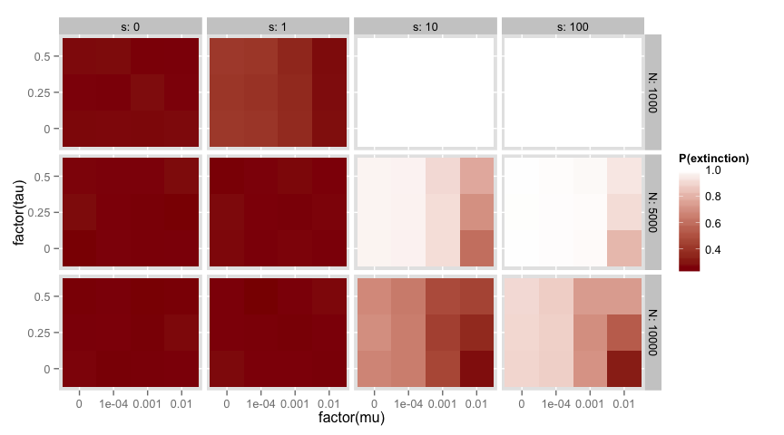

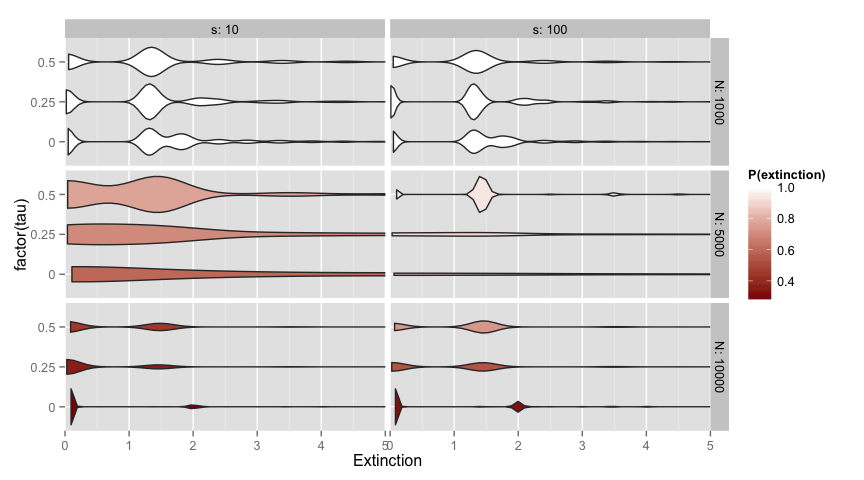

Figure 2. Distribution of the time to extinction (cropped to first 5 years as very little happens after that), with mu=0.01.

## 4.2 Simulation Series 3 - 2 July 2015

### 4.2.1 Deterministic dynamics

**Series 3 extended**: Ran deSolve across a large grid of parameter values with 2 to 8 patches on a ring. The local birth pulse determines the phase of epidemic cycles in each patch, irrespective of the migration rate.

Shiny markdown file.

### 4.2.2 Stochastic simulations

Source file: “Metapop Series 3.R”

Lifespan = 1 year, $R_0$ = 4, infectious period = 30.4166667 days, birth peak in patch 1: 0.5, migration rate: 0.01, peak sharpness 100. Infection seeded with 1 case in patch 1.

Parameters varied:

- Number of patches: 2, 4, 6, 8, arranged in a circular geometry.
- Maximum phase variation in birth peak across the metapopulation: 0, 0.25, 0.5, with a linear gradient from 0.5 in patch 1.
- $N$ (average population size in each patch): 1000, 5000, 10^{4}

For each of the 36 combinations, 5000 simulations were run for 20 years.

Run time: 48 hours on 15 cores on or226.

**Note (3 July):** extinctions were not recorded properly in the `sim.series.3` object. I have re-calculated individually from the RData files. The correct version of `sim.series.3` has been added to the file ‘Metapop Series 3.RData’.

### 4.2.3 View time-series

Uploaded simulations (100 per parameter combination) on [shinyapp.io](https://or226.shinyapps.io/Sim_series_3/Sim_series_3.Rmd)

### 4.2.4 Extinction

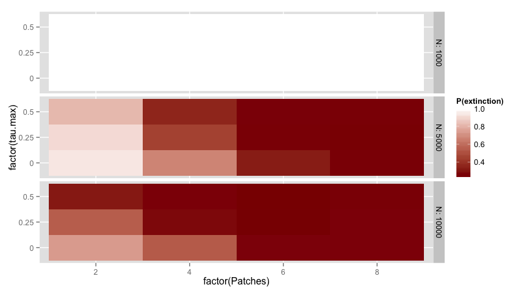

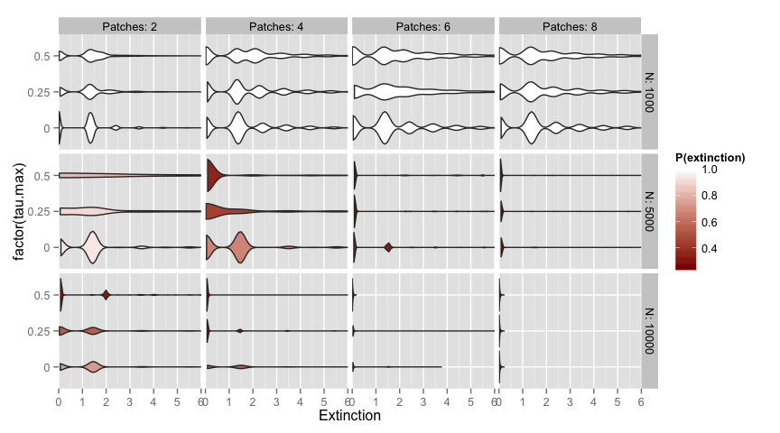

Figure 4. Distribution of the time to extinction (cropped to first 6 years as very little happens after that), with mu=0.0$.

### 4.2.5 Spatiotemporal dynamics

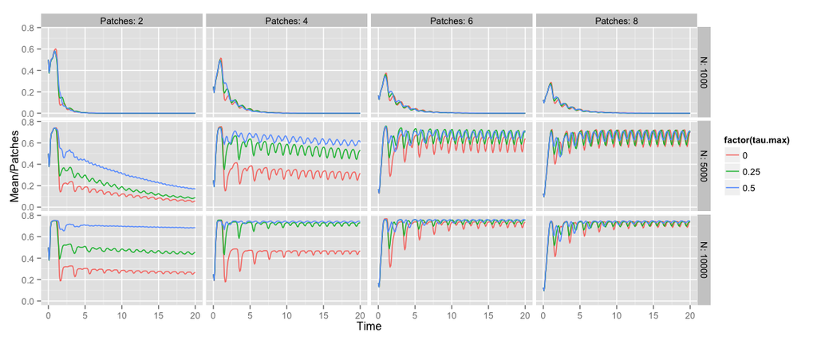

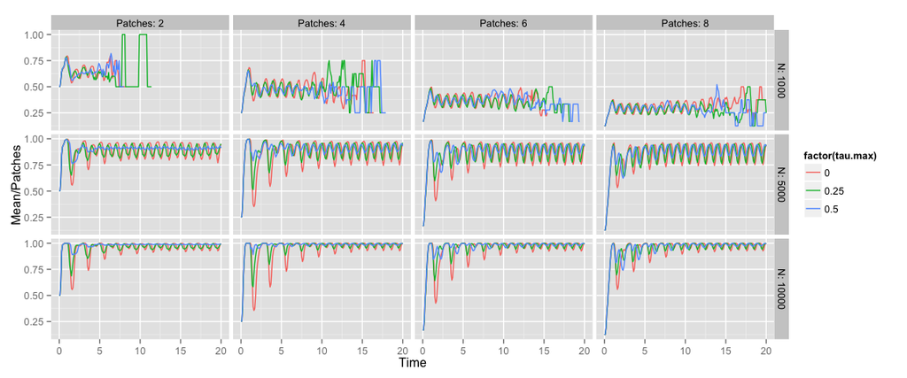

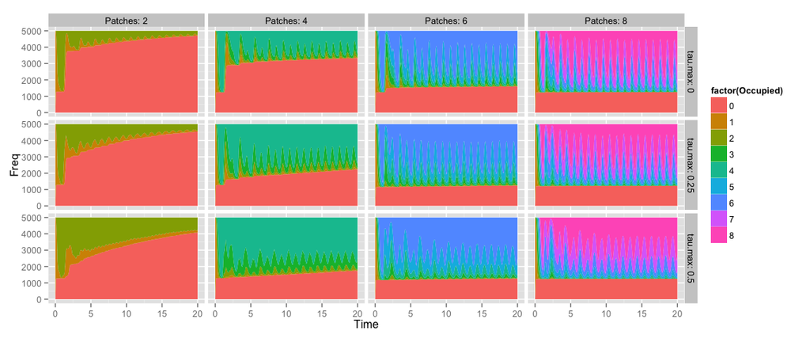

Figure 7. Distribution of the number of infected patches through time, shown for N=5000.

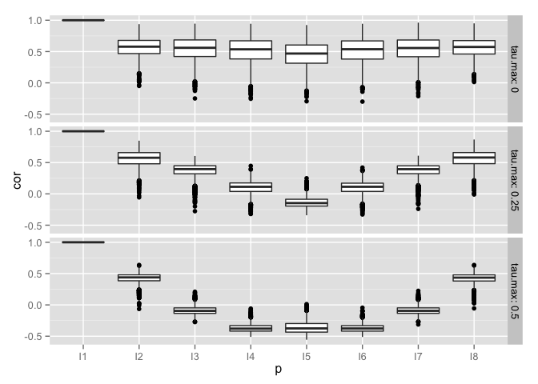

Figure 8. Distribution of correlation coefficients between I1 (time-series of number of infected individuals in patch 1) and each of the other In (n=2..8). Each boxplot represents the distribution of correlation coefficients across 5000 simulations. The time-series were cropped, removing the first year of each simulation.

## 4.3 Series 4: heterogeneous birth pulse tightness

Hypothesis: Patches with lower seasonality could act as reservoirs due to their lower CCS (Peel et al 2014).

Ran 8 series of 1000 simulations, with 2 or 4 patches of size 1000. Patch 1 has no birth pulse (s=0) and was seeded with 1 case. Migration rate was 0.01 per year, lifespan 1 year, R0=4 and infectious period = 1 month. All other patches have birth pulse, with s in the opposite patch ranging from 0 to 100.

### 4.3.1 Extinction

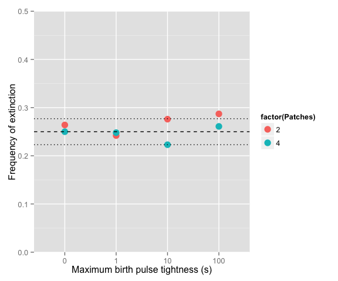

Figure 9. Probability of pathogen extinction within 20 years in the metapopulation.

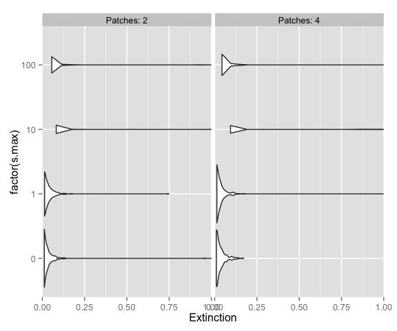

Figure 10. Distribution of the time to extinction (cropped to first year as very little happens after that), with mu=0.0$.

### 4.3.2 Spatiotemporal dynamics

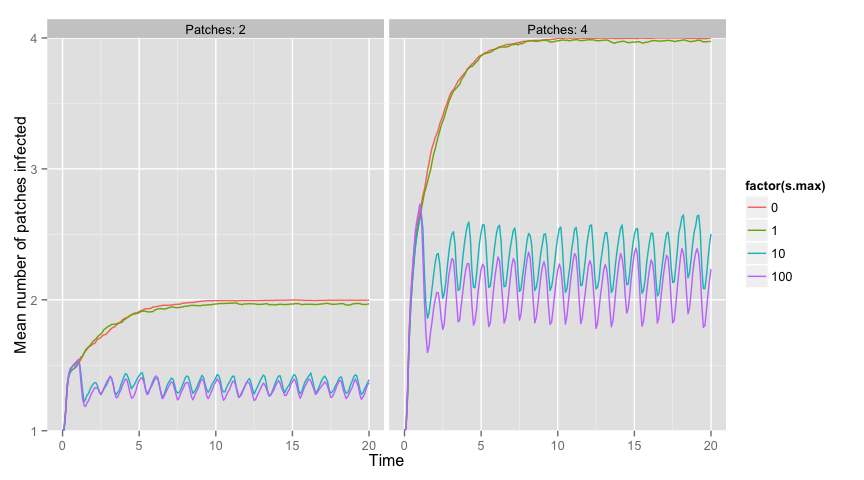

**——————————————————————————————–**

# 5 Results with density-dependent death rate

Source file.

## 5.1 Deterministic dynamics - Series 1

Comparison between the DDD and DID models show virtually identical infection dynamics (based on the same values for life span, infectious period, R0, s, tau and mu), but the DDD model prevents the increase in population size with high migration rate and asynchronous birth pulses. See shiny file.

## 5.2 Stochastic dynamics - Series 1

TBD.

**——————————————————————————————–**

# 6 Results with two competing strains and DDD

Source file.

Here I show results from series 3. I introduced two pathogen strains with the same $R_0$ but different infectious periods: the “acute” strain has an average infectious period of 1 month, and the “slow” strain 2 months. I varied the number of patches between 2 and 12 with a migration rate of 0.01 and a local carrying capacity of 5,000. Pulse tightness was either 1 or 10. The “acute” strain was introduced in patch 1 and the “slow” strain in eithe rpatch 2 or patch 7.

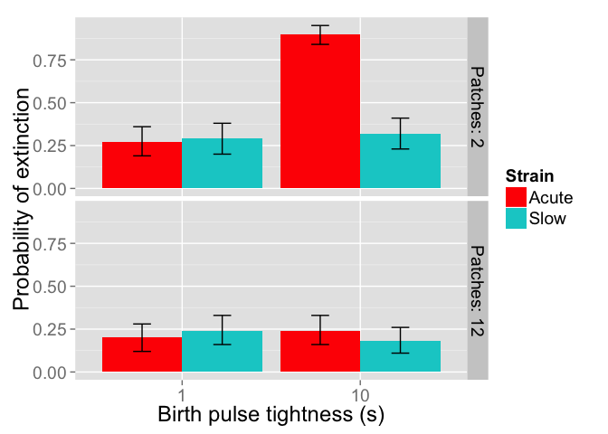

Figure 11. Probability of global extinction for each strain, depending on metapopulation size and tightness of birth pulse.

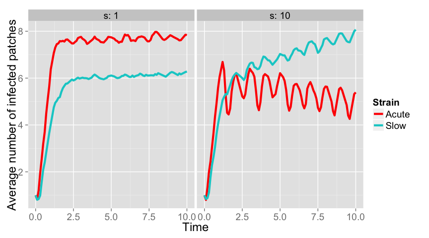

**——————————————————————————————–**

# 7 What’s next?

## 7.1 Other analyses

- Compare periodicity (frequency and phase) of $N_i(t)$, $I_i(t)$, $\Sigma N_i(t)$ and $\Sigma I_i(t)$.
  - In the deterministic model, strict annual periodicity following short transient period.
  - Stochastic simulations just above the CCS show more irregular patterns, probably driven by local extinctions.
- Estimate lag between patches

## 7.2 Further series

- Can high migration rates reduce phase variations?
  - The deterministic model suggests this may not be the case, at least when all patches have the same pulse tightness $s$.
- Geographic variation in pulse tightness.
- Effect of fragmentation (keep total N constant).
- Other geometries:
  - Source-sink dynamics
  - linear network
- Other parameter sets:
  - longer life-span
  - lower R0

## 7.3 Pathogen evolution

A simple idea would be to consider the $\beta-\gamma$ trade-off: for a given $R_0$, is a longer infectious period advantageous?

- Peel et al (2014): in a closed population, the CCS increases exponentially with the recovery rate.
- van Ballegoijen and Boerlijst(2004): lattice SIRS model with competing strains varying in transmission rate and infectious periods. Selection maximises outbreak frequency rather than $R_0$.
- Read and Keeling (2007): two-strain competition SIR model along an $R_0$ isocline in the $\beta-\gamma$ space. Stochastic simulations produce a bimodal fitness landscape. Slightly odd competition model.
- Of marginal interest, two modelling papers considered the emergence of a $\beta-\gamma$ trade-off from within-host dynamics: Alizon (2008) and King et al (2009).

Here it would probably make sense to introduce two different strains in two different patches.

## 7.4 Maternal immunity

As discussed with Ali and Raina, this would be a relevant extention of the model.